# Effects of sediment on the settlement rate of larval corals

Lillian J. Tuttle

9/25/2020

These datasets contain information from multiple articles (**Ref_name**) and studies/experiments (**Ref**) within those articles about the effects of DEPOSITED & SUSPENDED sediment on the **settlement rate** of larval corals, quantified as the percent of coral larvae (of those released) that successfully attach to experimental surfaces by the end of a given experiment. I would like to explore the dose-response relationship between sediment ‘dose’ and the effect size, estimated here as the standardized mean difference between treatment and control, in terms of Hedges’ *d*:

- Hedges’ *d* is the standardized mean difference between the treatment and control groups (Hedges and Olkin 1985). Each study may have multiple Hedges’ *d* calculations, one for each treatment-control comparison at each time-point.
- ‘Dose’ can be quantified as sediment exposure concentration (mg/cm<sup>2</sup>/day for deposited sediment and mg/L for suspended sediment), exposure duration (days), or as “cumulative exposure”, for which I multiply concentration and duration (mg/cm<sup>2</sup> for deposited sediment and mg x day/L for suspended sediment).

Each study/experiment (Ref) may contain multiple sets of controls and treatments (due to using multiple species or sediment types, for instance). Thus, I have added two categorical vectors, ‘**Comparison**’ and ‘Control’, which group each set of control-treatment comparisons into a unique two-letter code, within which is one control (Control==“1”) and at least one treatment (Control==“0”). **Therefore, ‘Comparison’ is nested within ‘Ref’, which is further nested within ‘Ref_name’.**

# I. Settlement rate

## A. Deposited Sediment

### 1. Plots

I calculated the standardized mean difference in terms of Hedges’ *d* and plot it here with respect to exposure concentration. I did this first for a Hedges’ *d* that I calculated before importing the data to R and again for a Hedges’ *d* that is calculated by the dosresmeta::covar.smd function.

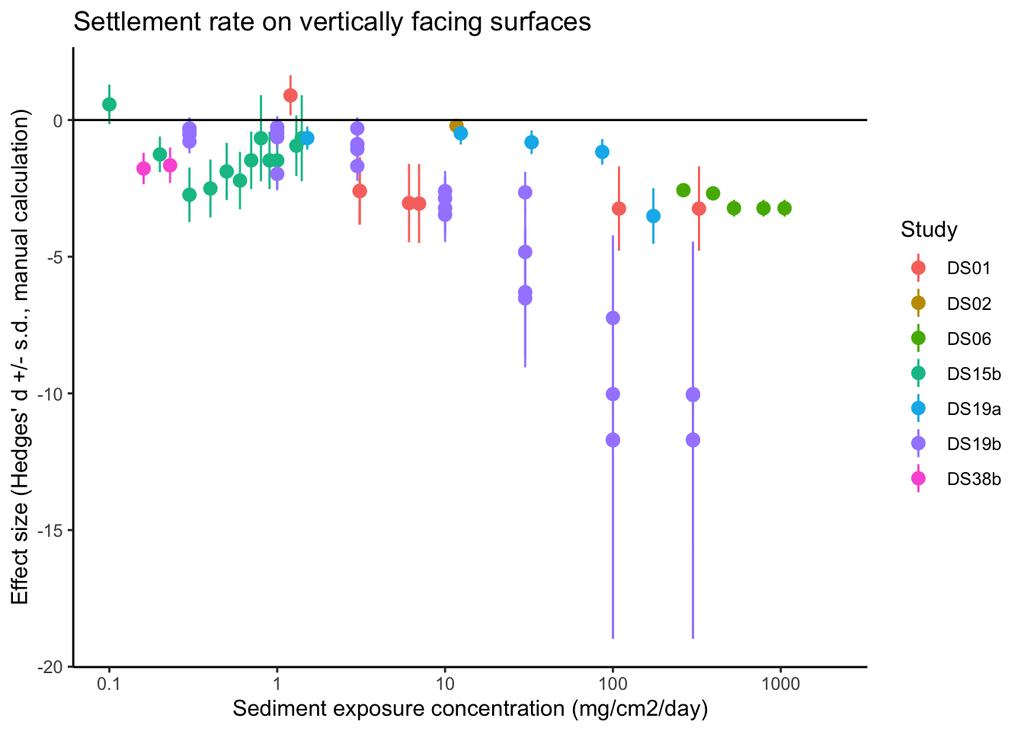

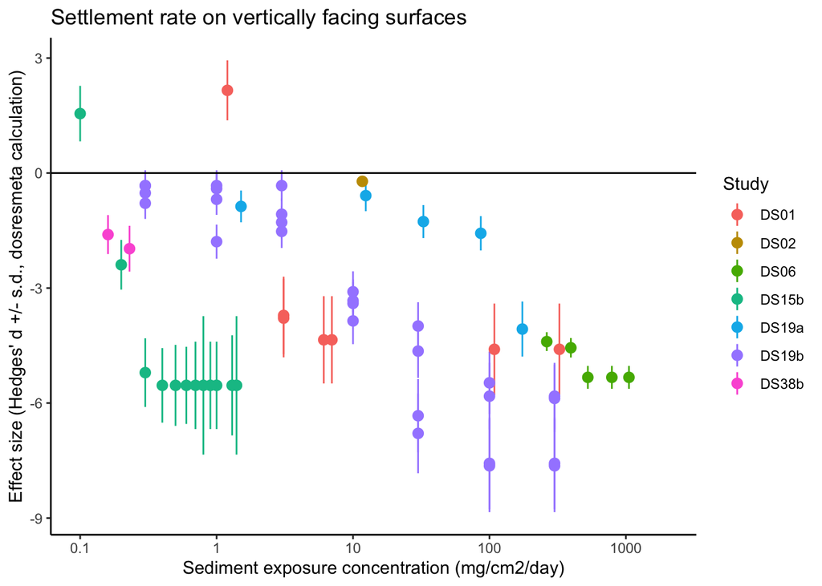

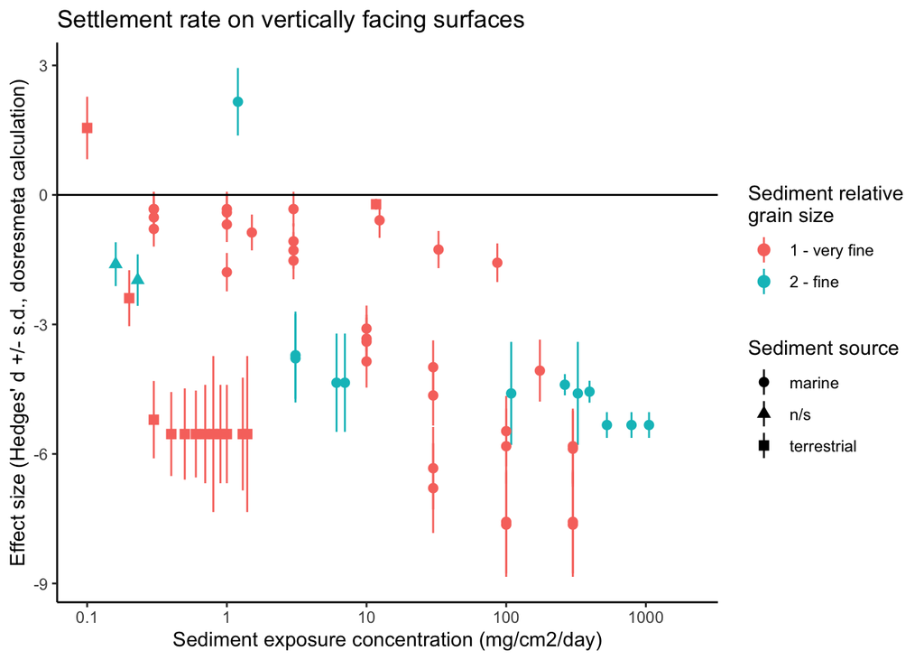

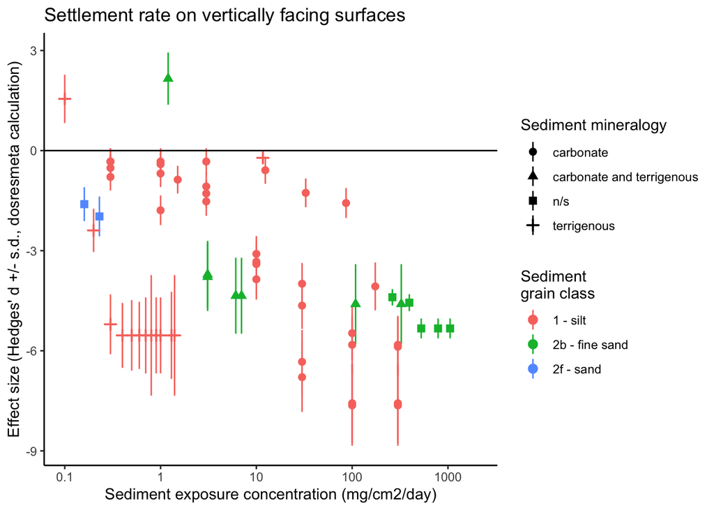

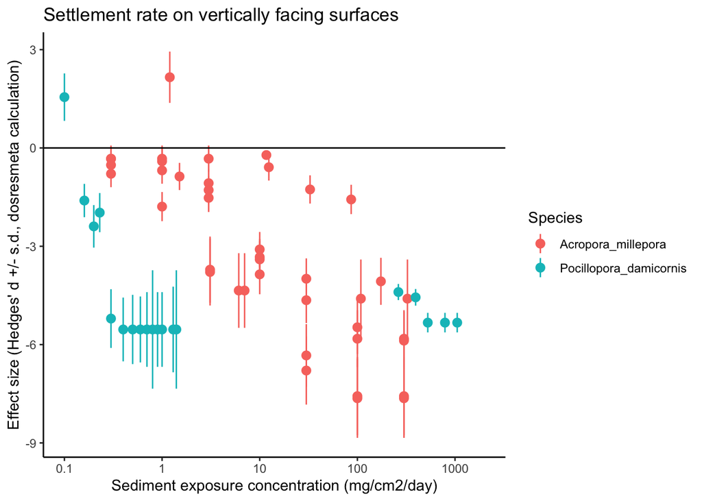

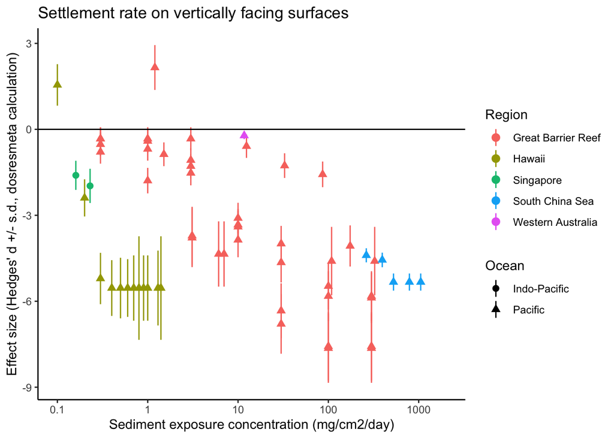

It is interesting that there is a difference between how I calculated Hedges’ *d* and how *dosresmeta* appears to calculate it. But in both cases, there may be a negative relationship between sediment exposure and effect size. There does not appear to be strong effects of phylogeny (genus) or geography (ocean and region). There may be effects of sediment type (source, origin, grain size), but I need to input these data to evaluate!

### 2. Model Fitting

The following set of functions model fixed and random (nested) effects WITHOUT accounting for within-comparison (or within-study) correlations. The output for each is a univariate, random-effects meta-regression.

To account for within-comparison correlations in the mixmeta model, I replace the ‘S’ argument with a ‘control’ argument, which requires me to provide the covariance matrices, as done with the covar.smd function.

And now to compare relative fit of linear models…

```
##                  df      AIC
## mod_DS_settle_1d  5 390.7752
## mod_DS_settle_2d  8 391.0384
## mod_DS_settle_3d  8 392.5466
## mod_DS_settle_4d 11 395.1244
## mod_DS_settle_5d  5 385.1074
## mod_DS_settle_6d  8 387.1865
```

And now to evaluate residuals of models…

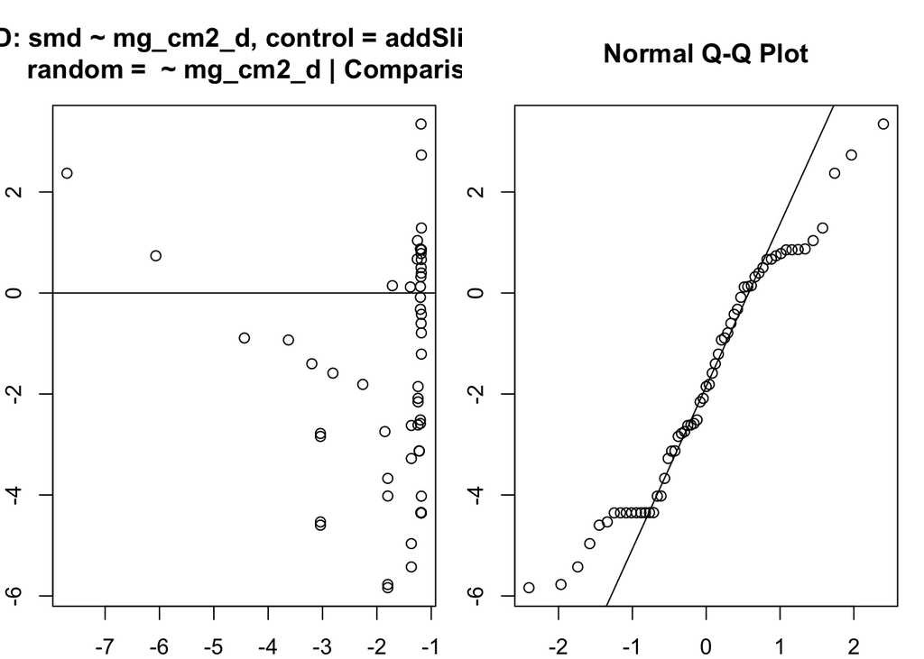

Now let’s check out a log, base 10 transformation of sediment exposure to see if it improves the residuals of the models.

To account for within-comparison correlations in the mixmeta model, I replace the ‘S’ argument with a ‘control’ argument, which requires me to provide the covariance matrices, as done with the covar.smd function.

And now to compare relative fit of linear models…

```
##                      df      AIC
## log_mod_DS_settle_1d  5 241.6665
## log_mod_DS_settle_2d  8 238.0581
## log_mod_DS_settle_3d  8 241.4291
## log_mod_DS_settle_4d 11 242.6467
## log_mod_DS_settle_5d  5 245.2860
## log_mod_DS_settle_6d  8 244.9488
```

And now to evaluate residuals of models…

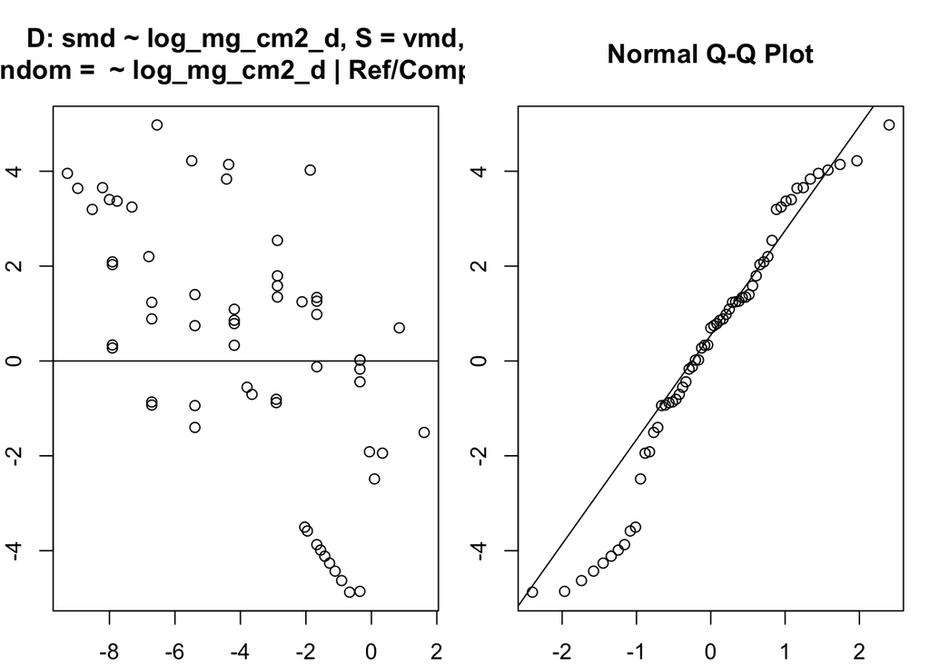

Patterns: 1. Residuals for best-fit model are very similar – transformations seem to have helped spread along fitted values axis and reduced magnitude of residuals. 2. No apparent need to look for non-linearities in data.

### 4. Best-Fit Model Summary

#### MG/CM<sup>2</sup>/DAY IS PREDICTOR, Model using dosresmeta calculation of Hedges’ *d*

Now I will predict the effect size along the exposure range and plot with confidence intervals.

```
## Call:  mixmeta(formula = smd ~ log10_mg_cm2_d, S = vmd, data = ES_DS_settlement2,
##     random = ~log10_mg_cm2_d | Ref/Comparison, method = "ml")
##
## Univariate extended random-effects meta-regression
## Dimension: 1
## Estimation method: ML
##
## Fixed-effects coefficients
##                 Estimate  Std. Error        z  Pr(>|z|)  95%ci.lb  95%ci.ub
## (Intercept)      -1.6670      0.9329  -1.7870    0.0739   -3.4954    0.1614
## log10_mg_cm2_d   -2.5204      0.5608  -4.4944    0.0000   -3.6196   -1.4213
##
## (Intercept)       .
## log10_mg_cm2_d  ***
## ---
## Signif. codes:  0 '***' 0.001 '**' 0.01 '*' 0.05 '.' 0.1 ' ' 1
##
## Random-effects (co)variance components
##  Formula: ~log10_mg_cm2_d | Ref
##  Structure: General positive-definite
##                 Std. Dev         Corr
## (Intercept)       2.4172  (Intercept)
## log10_mg_cm2_d    1.3725            1
##
##  Formula: ~log10_mg_cm2_d | Comparison
##  Structure: General positive-definite
##                 Std. Dev         Corr
## (Intercept)       0.0896  (Intercept)
## log10_mg_cm2_d    0.3202           -1
##
## Univariate Cochran Q-test for residual heterogeneity:
## Q = 384.0160 (df = 59), p-value = 0.0000
## I-square statistic = 84.6%
##
## 61 units, 1 outcome, 61 observations, 2 fixed and 6 random-effects parameters
##    logLik        AIC        BIC
## -111.0290   238.0581   254.9451
```

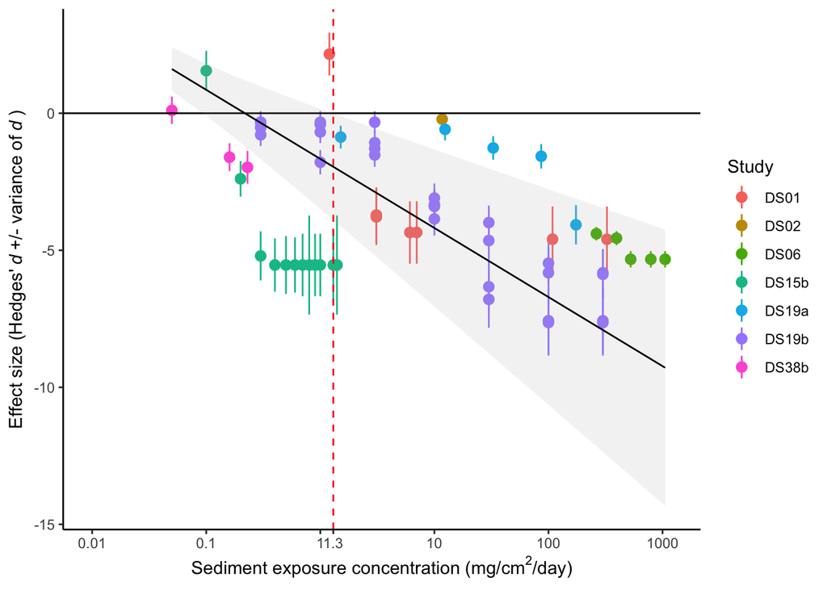

For every 10-fold increase in exposure concentration of deposited sediment, the Hedges’ d effect size for settlement rate of coral larvae declined by 2.5 (95% CI -3.6, -1.4; DRMA z = -4.494, p < 0.0001), after accounting for variability by comparison (Fig. X, Table X). However, the best-fit model’s I2 statistic was 84.6%, indicating considerable residual heterogeneity unaccounted for by the model (Table X), which could be the result of taxonomic, geographic, and/or mineralogical differences among (and within) studies.

## B. Suspended Sediment

### 1. Plots

I calculated the standardized mean difference in terms of Hedges’ *d* and plot it here with respect to exposure concentration. I did this first for a Hedges’ *d* that I calculated before importing the data to R and again for a Hedges’ *d* that is calculated by the dosresmeta::covar.smd function.

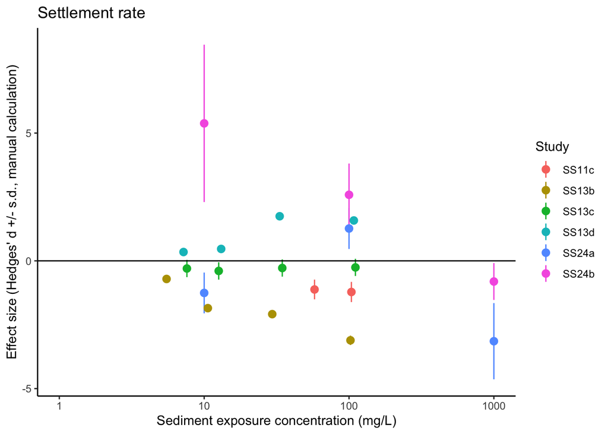

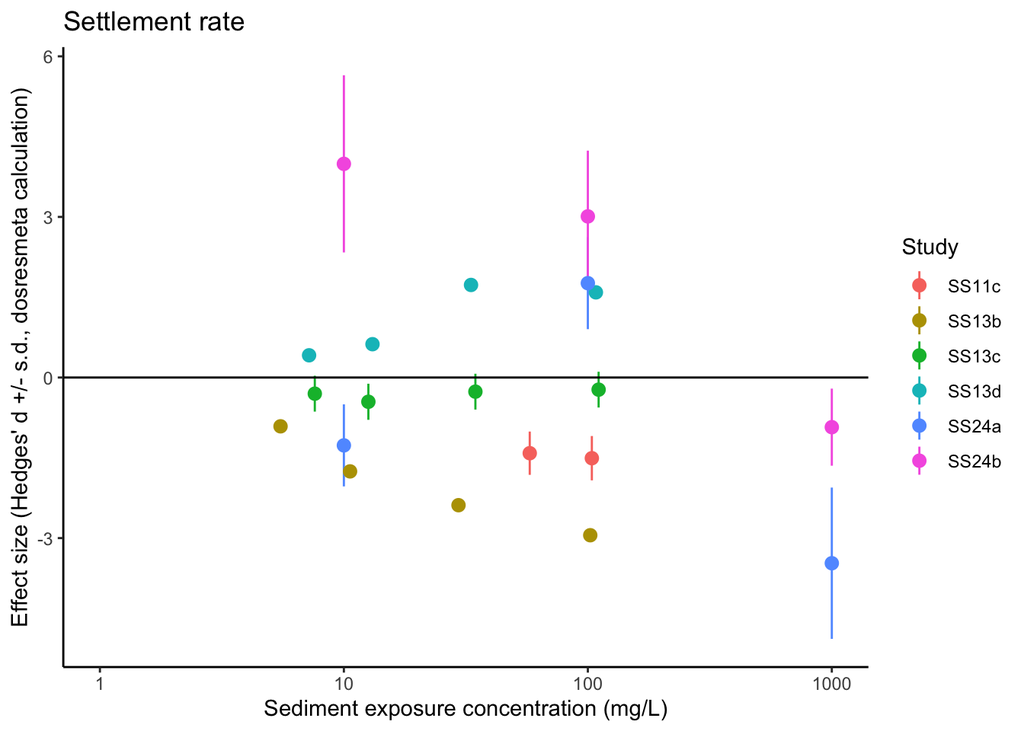

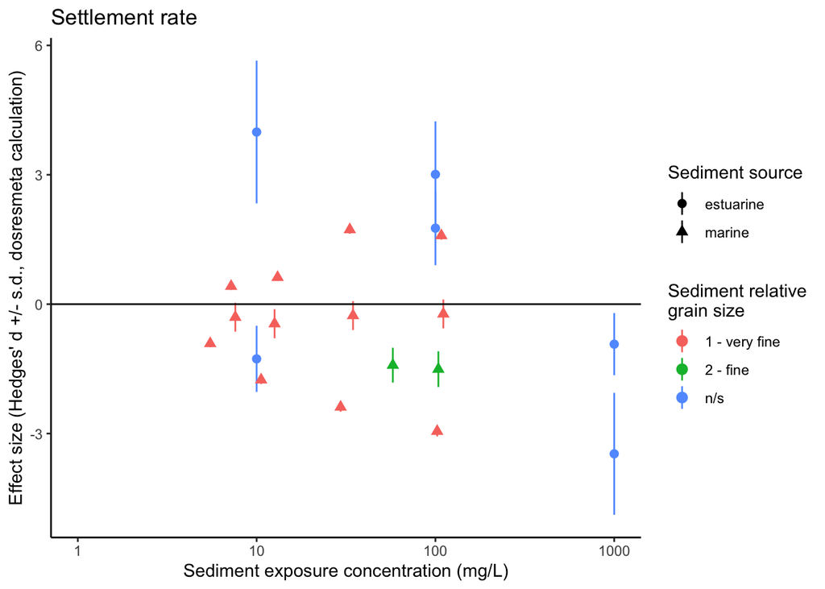

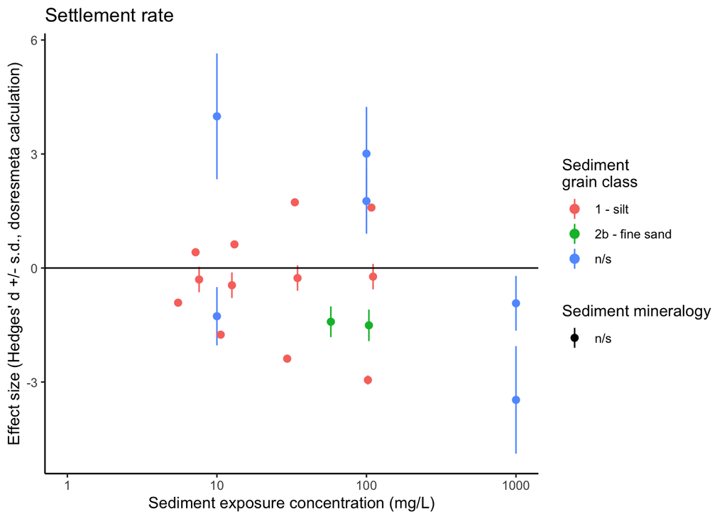

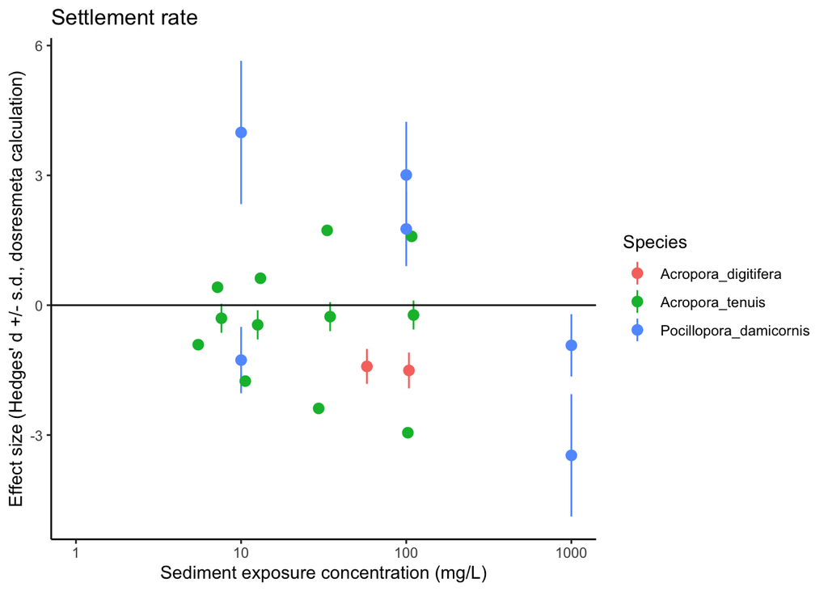

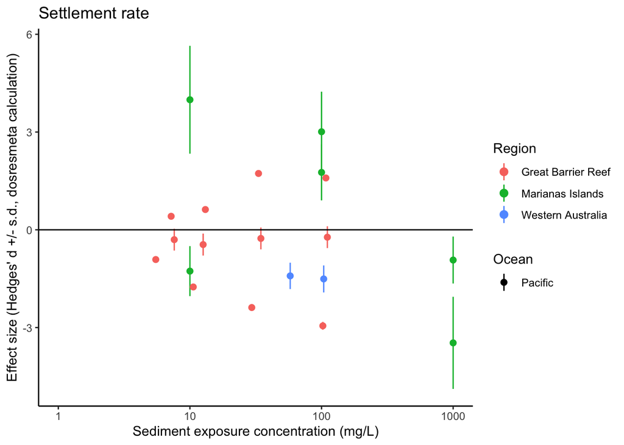

It is interesting that there is a difference between how I calculated Hedges’ *d* and how *dosresmeta* appears to calculate it. But in both cases, there is not strong evidence for a relationship between sediment exposure and effect size. There is not strong evidence of an effect by phylogeny (genus), geography (ocean and region), or sediment type (source, origin, grain size).

### 2. Model Fitting

The following set of functions model fixed and random (nested) effects WITHOUT accounting for within-comparison (or within-study) correlations. The output for each is a univariate, random-effects meta-regression.

To account for within-comparison correlations in the mixmeta model, I replace the ‘S’ argument with a ‘control’ argument, which requires me to provide the covariance matrices, as done with the covar.smd function.

And now to compare relative fit of linear models…

```
##                  df      AIC
## mod_SS_settle_1d  5 84.36410
## mod_SS_settle_3d  8 90.10160
## mod_SS_settle_5d  5 90.25010
## mod_SS_settle_7d  8 96.24988
```

And now to evaluate residuals of models…

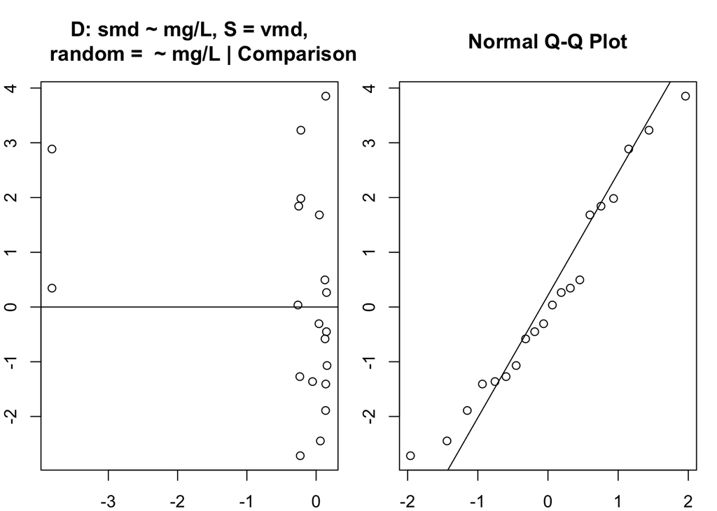

Patterns: 1. Residuals are very similar – YIKES! may need some transformations. 2. There could be non-linearities that need to be accounted for. 3. First let’s try a log transformation of sediment exposure before adding non-linear models.

Now let’s check out a log, base 10 transformation of sediment exposure to see if it improves the residuals of the models.

To account for within-comparison correlations in the mixmeta model, I replace the ‘S’ argument with a ‘control’ argument, which requires me to provide the covariance matrices, as done with the covar.smd function.

### 3. Model Comparison and Summary

And now to compare relative fit of log-linear models…

```
##                      df      AIC
## log_mod_SS_settle_1d  5 80.49922
## log_mod_SS_settle_3d  8 84.83991
## log_mod_SS_settle_5d  5 71.02839
## log_mod_SS_settle_7d  8 77.02839
```

And now to evaluate residuals of models…

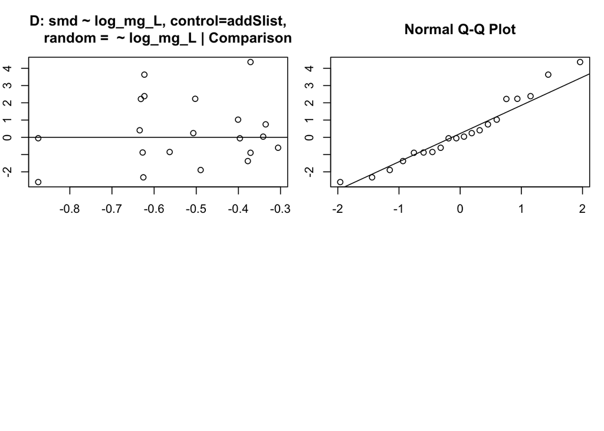

### 4. Best-Fit Model Summary

#### MG/L IS PREDICTOR, Model using dosresmeta calculation of Hedges’ *d*

Now I will predict the effect size along the exposure range and plot with confidence intervals.

```
## Call:  mixmeta(formula = smd ~ log10_mg_L, data = ES_SS_settlement2,
##     random = ~log10_mg_L | Comparison, method = "ml", control = list(addSlist = newlist_log_SETT_SS))
##
## Univariate extended random-effects meta-regression
## Dimension: 1
## Estimation method: ML
##
## Fixed-effects coefficients
##              Estimate  Std. Error        z  Pr(>|z|)  95%ci.lb  95%ci.ub
## (Intercept)   -0.1194      0.2466  -0.4840    0.6284   -0.6028    0.3641
## log10_mg_L    -0.2519      0.3501  -0.7193    0.4719   -0.9381    0.4344
## ---
## Signif. codes:  0 '***' 0.001 '**' 0.01 '*' 0.05 '.' 0.1 ' ' 1
##
## Random-effects (co)variance components
##  Formula: ~log10_mg_L | Comparison
##  Structure: General positive-definite
##              Std. Dev         Corr
## (Intercept)    0.1255  (Intercept)
## log10_mg_L     0.7797           -1
##
## Univariate Cochran Q-test for residual heterogeneity:
## Q = 153.9011 (df = 18), p-value = 0.0000
## I-square statistic = 88.3%
##
## 20 units, 1 outcome, 20 observations, 2 fixed and 3 random-effects parameters
##   logLik       AIC       BIC
## -30.5142   71.0284   76.0070
```

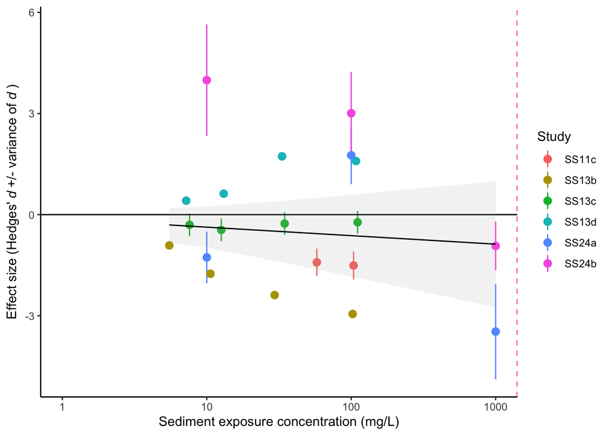

There is no significant relationship between exposure concentration to suspended sediment and the Hedges’ d effect size for settlement rate of coral larvae (DRMA z = -0.719, p = 0.472).